# DSCC462_FinalProject

Q5.(a)

```r
ads_mobile = ads[ads$mobile == 'mobile',]
ads_mobile['profit'] = ads_mobile$adrevenue - ads_mobile$adcost

ads_mobile
```

```
##     socialmedia age mobile season newcustomer adcost adrevenue profit
## 2     Instagram  31 mobile   fall          no   5.34      9.40   4.06
## 3      Facebook  24 mobile spring         yes   6.65      5.22  -1.43
## 4     Instagram  29 mobile summer         yes   5.43      7.66   2.23
## 6      Facebook  35 mobile   fall          no   6.61      1.46  -5.15
## 7        TikTok  21 mobile summer          no   0.21      6.52   6.31
## 8        TikTok  16 mobile   fall          no   7.75     13.38   5.63
## 9        TikTok  18 mobile spring         yes   7.12      4.69  -2.43
## 11      YouTube  21 mobile spring          no  14.93     17.90   2.97
## 12    Instagram  25 mobile summer         yes   7.05      1.92  -5.13
## 13    Instagram  31 mobile spring          no   7.39     19.75  12.36
## 17       TikTok  17 mobile summer         yes   0.80      0.80   0.00
## 18       TikTok  15 mobile   fall          no   0.68      1.29   0.61
## 20       TikTok  17 mobile summer          no   1.99      1.88  -0.11
## 21       TikTok  19 mobile winter         yes   6.97     14.64   7.67
```

[output cut: 244 more lines]

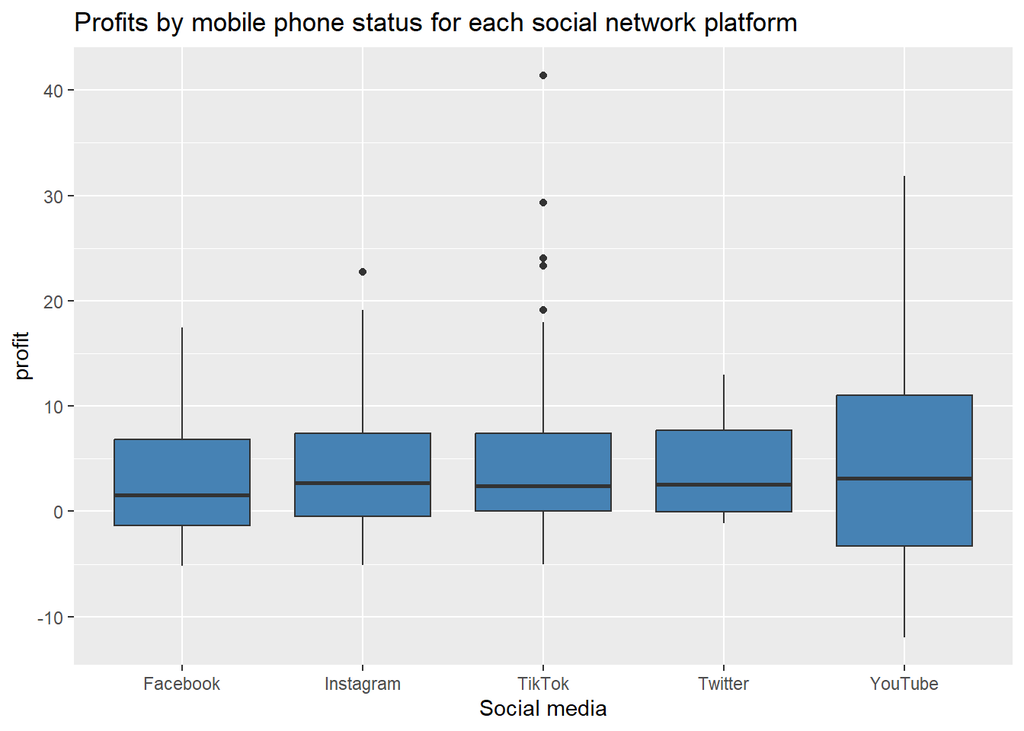

```r
ggplot(ads_mobile, aes(x=socialmedia, y=profit)) +
  geom_boxplot(fill="steelblue") + labs(title="Profits by mobile phone status for each social network platform",x="Social media",y="profit")
```

```r
ads_comp = ads[ads$mobile == 'computer',]
ads_comp['profit'] = ads_comp$adrevenue - ads_comp$adcost

ads_comp
```

```
##     socialmedia age   mobile season newcustomer adcost adrevenue profit
## 1       YouTube  18 computer summer          no  11.97     55.82  43.85
## 5       YouTube  32 computer summer          no  11.82      4.61  -7.21
## 10      YouTube  26 computer spring         yes  13.34     10.17  -3.17
## 14     Facebook  20 computer winter          no   4.38      5.39   1.01
## 15      YouTube  30 computer   fall         yes  11.12     45.30  34.18
## 16      YouTube  34 computer   fall          no  11.31     65.50  54.19
## 19      YouTube  35 computer   fall         yes  12.96     29.14  16.18
## 23    Instagram  30 computer   fall         yes   6.18      7.95   1.77
## 30      YouTube  48 computer   fall          no  12.40     52.73  40.33
## 33      YouTube  40 computer   fall         yes  10.88     15.52   4.64
## 34      YouTube  29 computer spring          no   7.26     13.01   5.75
## 35      YouTube  17 computer summer          no   9.50      3.14  -6.36
## 36      YouTube  42 computer spring          no  10.21     56.18  45.97
## 37      YouTube  37 computer spring          no  14.81     64.23  49.42
```

[output cut: 138 more lines]

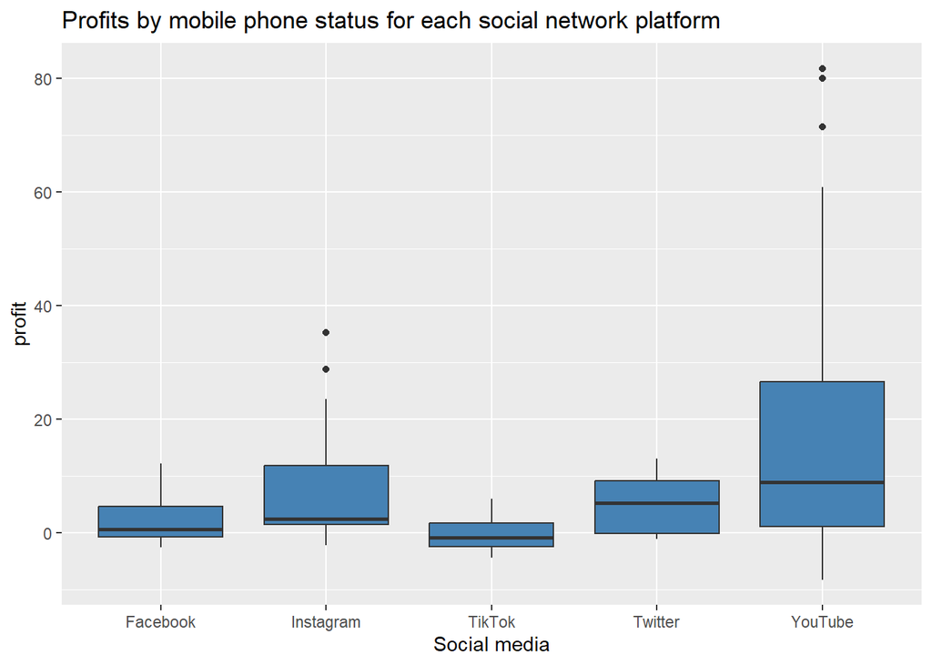

```r
ggplot(ads_comp, aes(x=socialmedia, y=profit)) +
  geom_boxplot(fill="steelblue") + labs(title="Profits by mobile phone status for each social network platform",x="Social media",y="profit")
```

For mobile users, we can see that median for all social media platforms is almost the same. TikTok has the most number of high profit outliers. For computer users, YouTube has the maximum IQR and also some high profit outliers.

Q5.(b)

H0 : Mean_Profit(FB) = Mean_Profit(Twitter) = …. = Mean_Profit(Instagram) H1 : At least one of the population mean differs from one of the other

```r
model = aov(ads_mobile$profit ~ ads_mobile$socialmedia)

summary(model)
```

```
##                         Df Sum Sq Mean Sq F value Pr(>F)
## ads_mobile$socialmedia   4     84   21.11   0.415  0.798
## Residuals              253  12859   50.83
```

P value > Alpha(0.05) We failed to reject the Null Hypothesis. Hence, we can conclude that the mean profit for each social media platform is the same.